# Risk Factor Analysis

## Outcome Variable

**Outcome Variable:** y_rate_wtkg

## Predictor Variables

**Intervention Variable:** nhh

**Adjustment Set:**

- arm
- W_mage
- meducyrs
- feducyrs
- W_mhtcm
- W_mwtkg
- W_mbmi
- W_nrooms
- trth2o
- cleanck
- impfloor
- impsan
- safeh20
- delta_W_mage
- delta_meducyrs
- delta_feducyrs
- delta_W_mhtcm
- delta_W_mwtkg
- delta_W_mbmi
- delta_W_nrooms
- delta_trth2o
- delta_cleanck
- delta_impfloor
- delta_impsan
- delta_safeh20

## Stratifying Variables

The analysis was stratified on these variable(s):

- agecat
- studyid
- country

## Data Summary

| agecat | studyid | country | nhh | n_cell | n |
| --- | --- | --- | --- | --- | --- |
| 0-3 months | IRC | INDIA | 3 or less | 57 | 394 |
| 0-3 months | IRC | INDIA | 4-5 | 151 | 394 |
| 0-3 months | IRC | INDIA | 6-7 | 101 | 394 |
| 0-3 months | IRC | INDIA | 8+ | 85 | 394 |
| 0-3 months | NIH-Birth | BANGLADESH | 3 or less | 101 | 565 |
| 0-3 months | NIH-Birth | BANGLADESH | 4-5 | 238 | 565 |
| 0-3 months | NIH-Birth | BANGLADESH | 6-7 | 132 | 565 |
| 0-3 months | NIH-Birth | BANGLADESH | 8+ | 94 | 565 |
| 0-3 months | NIH-Crypto | BANGLADESH | 3 or less | 110 | 725 |
| 0-3 months | NIH-Crypto | BANGLADESH | 4-5 | 324 | 725 |
| 0-3 months | NIH-Crypto | BANGLADESH | 6-7 | 171 | 725 |
| 0-3 months | NIH-Crypto | BANGLADESH | 8+ | 120 | 725 |
| 0-3 months | PROVIDE | BANGLADESH | 3 or less | 123 | 640 |
| 0-3 months | PROVIDE | BANGLADESH | 4-5 | 296 | 640 |
| 0-3 months | PROVIDE | BANGLADESH | 6-7 | 136 | 640 |
| 0-3 months | PROVIDE | BANGLADESH | 8+ | 85 | 640 |
| 3-6 months | IRC | INDIA | 3 or less | 57 | 399 |
| 3-6 months | IRC | INDIA | 4-5 | 153 | 399 |
| 3-6 months | IRC | INDIA | 6-7 | 104 | 399 |
| 3-6 months | IRC | INDIA | 8+ | 85 | 399 |
| 3-6 months | NIH-Birth | BANGLADESH | 3 or less | 89 | 522 |
| 3-6 months | NIH-Birth | BANGLADESH | 4-5 | 223 | 522 |
| 3-6 months | NIH-Birth | BANGLADESH | 6-7 | 125 | 522 |
| 3-6 months | NIH-Birth | BANGLADESH | 8+ | 85 | 522 |
| 3-6 months | NIH-Crypto | BANGLADESH | 3 or less | 103 | 702 |
| 3-6 months | NIH-Crypto | BANGLADESH | 4-5 | 317 | 702 |
| 3-6 months | NIH-Crypto | BANGLADESH | 6-7 | 167 | 702 |
| 3-6 months | NIH-Crypto | BANGLADESH | 8+ | 115 | 702 |
| 3-6 months | PROVIDE | BANGLADESH | 3 or less | 105 | 601 |
| 3-6 months | PROVIDE | BANGLADESH | 4-5 | 287 | 601 |

[output cut: 138 more lines]

The following strata were considered:

- agecat: 0-3 months, studyid: IRC, country: INDIA
- agecat: 0-3 months, studyid: NIH-Birth, country: BANGLADESH
- agecat: 0-3 months, studyid: NIH-Crypto, country: BANGLADESH
- agecat: 0-3 months, studyid: PROVIDE, country: BANGLADESH
- agecat: 12-15 months, studyid: IRC, country: INDIA
- agecat: 12-15 months, studyid: LCNI-5, country: MALAWI
- agecat: 12-15 months, studyid: NIH-Birth, country: BANGLADESH
- agecat: 12-15 months, studyid: NIH-Crypto, country: BANGLADESH
- agecat: 12-15 months, studyid: PROVIDE, country: BANGLADESH
- agecat: 12-15 months, studyid: SAS-FoodSuppl, country: INDIA
- agecat: 15-18 months, studyid: IRC, country: INDIA
- agecat: 15-18 months, studyid: LCNI-5, country: MALAWI
- agecat: 15-18 months, studyid: NIH-Birth, country: BANGLADESH
- agecat: 15-18 months, studyid: NIH-Crypto, country: BANGLADESH
- agecat: 15-18 months, studyid: PROVIDE, country: BANGLADESH
- agecat: 15-18 months, studyid: SAS-FoodSuppl, country: INDIA
- agecat: 18-21 months, studyid: IRC, country: INDIA
- agecat: 18-21 months, studyid: LCNI-5, country: MALAWI
- agecat: 18-21 months, studyid: NIH-Birth, country: BANGLADESH
- agecat: 18-21 months, studyid: NIH-Crypto, country: BANGLADESH
- agecat: 18-21 months, studyid: PROVIDE, country: BANGLADESH
- agecat: 21-24 months, studyid: IRC, country: INDIA
- agecat: 21-24 months, studyid: LCNI-5, country: MALAWI
- agecat: 21-24 months, studyid: NIH-Birth, country: BANGLADESH
- agecat: 21-24 months, studyid: NIH-Crypto, country: BANGLADESH
- agecat: 21-24 months, studyid: PROVIDE, country: BANGLADESH
- agecat: 3-6 months, studyid: IRC, country: INDIA
- agecat: 3-6 months, studyid: NIH-Birth, country: BANGLADESH
- agecat: 3-6 months, studyid: NIH-Crypto, country: BANGLADESH
- agecat: 3-6 months, studyid: PROVIDE, country: BANGLADESH
- agecat: 6-9 months, studyid: IRC, country: INDIA
- agecat: 6-9 months, studyid: LCNI-5, country: MALAWI
- agecat: 6-9 months, studyid: NIH-Birth, country: BANGLADESH
- agecat: 6-9 months, studyid: NIH-Crypto, country: BANGLADESH
- agecat: 6-9 months, studyid: PROVIDE, country: BANGLADESH
- agecat: 6-9 months, studyid: SAS-FoodSuppl, country: INDIA
- agecat: 9-12 months, studyid: IRC, country: INDIA
- agecat: 9-12 months, studyid: LCNI-5, country: MALAWI
- agecat: 9-12 months, studyid: NIH-Birth, country: BANGLADESH
- agecat: 9-12 months, studyid: NIH-Crypto, country: BANGLADESH
- agecat: 9-12 months, studyid: PROVIDE, country: BANGLADESH
- agecat: 9-12 months, studyid: SAS-FoodSuppl, country: INDIA

## Methods Detail

We’re interested in the causal parameters $E[Y_a]$ for all values of $a \in \mathcal{A}$. These parameters represent the mean outcome if, possibly contrary to fact, we intervened to set all units to have $A=a$. Under the randomization and positivity assumptions, these are identified by the statistical parameters $\psi_a=E_W[E_{Y|A,W}(Y|A=a,W)]$. In addition, we’re interested in the mean of $Y$, $E[Y]$ under no intervention (the observed mean). We will estimate these parameters by using SuperLearner to fit the relevant likelihood factors – $E_{Y|A,W}(Y|A=a,W)$ and $p(A=a|W)$, and then updating our likelihood fit using a joint TMLE.

For unadjusted analyses ($W=\{\}$), initial likelihoods were estimated using Lrnr_glm to estimate the simple $E(Y|A)$ and Lrnr_mean to estimate $p(A)$. For adjusted analyses, a small library containing Lrnr_glmnet, Lrnr_xgboost, and Lrnr_mean was used.

Having estimated these parameters, we will then use the delta method to estimate relative risks and attributable risks relative to a prespecified baseline level of $A$.

# Results Detail

## Results Plots

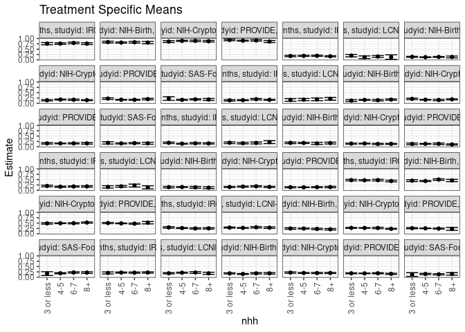

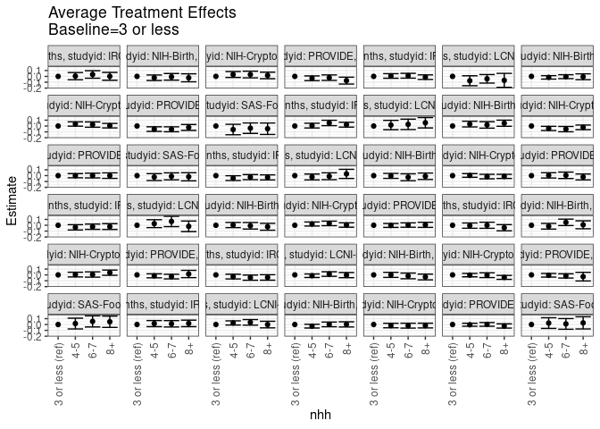

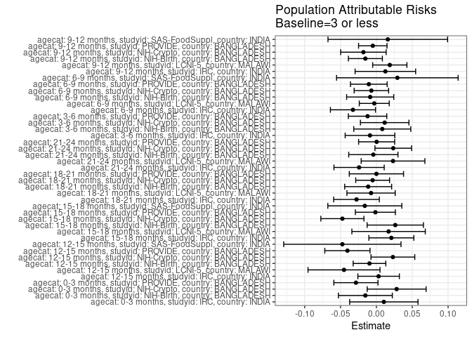

## Results Table

### Parameter: TSM

| agecat | studyid | country | intervention_level | baseline_level | estimate | ci_lower | ci_upper |
| --- | --- | --- | --- | --- | --- | --- | --- |
| 0-3 months | IRC | INDIA | 3 or less | NA | 0.7575861 | 0.7063512 | 0.8088209 |
| 0-3 months | IRC | INDIA | 4-5 | NA | 0.7616508 | 0.7271566 | 0.7961451 |
| 0-3 months | IRC | INDIA | 6-7 | NA | 0.7902348 | 0.7519964 | 0.8284732 |
| 0-3 months | IRC | INDIA | 8+ | NA | 0.7585038 | 0.7152752 | 0.8017324 |
| 0-3 months | NIH-Birth | BANGLADESH | 3 or less | NA | 0.8317242 | 0.7917735 | 0.8716748 |
| 0-3 months | NIH-Birth | BANGLADESH | 4-5 | NA | 0.8084446 | 0.7836443 | 0.8332449 |
| 0-3 months | NIH-Birth | BANGLADESH | 6-7 | NA | 0.8240689 | 0.7840255 | 0.8641123 |
| 0-3 months | NIH-Birth | BANGLADESH | 8+ | NA | 0.8075729 | 0.7527074 | 0.8624384 |
| 0-3 months | NIH-Crypto | BANGLADESH | 3 or less | NA | 0.8562725 | 0.8135274 | 0.8990175 |
| 0-3 months | NIH-Crypto | BANGLADESH | 4-5 | NA | 0.8882134 | 0.8618270 | 0.9145998 |
| 0-3 months | NIH-Crypto | BANGLADESH | 6-7 | NA | 0.8879420 | 0.8505930 | 0.9252910 |
| 0-3 months | NIH-Crypto | BANGLADESH | 8+ | NA | 0.8724972 | 0.8365883 | 0.9084061 |
| 0-3 months | PROVIDE | BANGLADESH | 3 or less | NA | 0.9301763 | 0.8962434 | 0.9641091 |
| 0-3 months | PROVIDE | BANGLADESH | 4-5 | NA | 0.8975469 | 0.8753692 | 0.9197246 |
| 0-3 months | PROVIDE | BANGLADESH | 6-7 | NA | 0.9080525 | 0.8754964 | 0.9406085 |
| 0-3 months | PROVIDE | BANGLADESH | 8+ | NA | 0.8578797 | 0.8104443 | 0.9053151 |
| 3-6 months | IRC | INDIA | 3 or less | NA | 0.4749998 | 0.4393534 | 0.5106462 |
| 3-6 months | IRC | INDIA | 4-5 | NA | 0.4690650 | 0.4420534 | 0.4960766 |
| 3-6 months | IRC | INDIA | 6-7 | NA | 0.4751605 | 0.4374862 | 0.5128348 |
| 3-6 months | IRC | INDIA | 8+ | NA | 0.4333596 | 0.3945016 | 0.4722177 |
| 3-6 months | NIH-Birth | BANGLADESH | 3 or less | NA | 0.4511895 | 0.4088251 | 0.4935540 |
| 3-6 months | NIH-Birth | BANGLADESH | 4-5 | NA | 0.4339253 | 0.4100224 | 0.4578281 |
| 3-6 months | NIH-Birth | BANGLADESH | 6-7 | NA | 0.5010307 | 0.4662468 | 0.5358146 |
| 3-6 months | NIH-Birth | BANGLADESH | 8+ | NA | 0.4591599 | 0.4064758 | 0.5118440 |
| 3-6 months | NIH-Crypto | BANGLADESH | 3 or less | NA | 0.4864820 | 0.4515587 | 0.5214052 |
| 3-6 months | NIH-Crypto | BANGLADESH | 4-5 | NA | 0.4919971 | 0.4727430 | 0.5112511 |
| 3-6 months | NIH-Crypto | BANGLADESH | 6-7 | NA | 0.4929235 | 0.4644409 | 0.5214061 |
| 3-6 months | NIH-Crypto | BANGLADESH | 8+ | NA | 0.5238784 | 0.4956288 | 0.5521279 |
| 3-6 months | PROVIDE | BANGLADESH | 3 or less | NA | 0.5013573 | 0.4722890 | 0.5304255 |
| 3-6 months | PROVIDE | BANGLADESH | 4-5 | NA | 0.4855777 | 0.4679417 | 0.5032136 |

[output cut: 138 more lines]

### Parameter: E(Y)

| agecat | studyid | country | intervention_level | baseline_level | estimate | ci_lower | ci_upper |
| --- | --- | --- | --- | --- | --- | --- | --- |
| 0-3 months | IRC | INDIA | NA | NA | 0.7679906 | 0.7485485 | 0.7874326 |
| 0-3 months | NIH-Birth | BANGLADESH | NA | NA | 0.8163500 | 0.7995330 | 0.8331670 |
| 0-3 months | NIH-Crypto | BANGLADESH | NA | NA | 0.8845220 | 0.8699746 | 0.8990694 |
| 0-3 months | PROVIDE | BANGLADESH | NA | NA | 0.9016472 | 0.8868914 | 0.9164029 |
| 3-6 months | IRC | INDIA | NA | NA | 0.4660717 | 0.4485044 | 0.4836390 |
| 3-6 months | NIH-Birth | BANGLADESH | NA | NA | 0.4593975 | 0.4422221 | 0.4765729 |
| 3-6 months | NIH-Crypto | BANGLADESH | NA | NA | 0.4980544 | 0.4869892 | 0.5091196 |
| 3-6 months | PROVIDE | BANGLADESH | NA | NA | 0.4890611 | 0.4760060 | 0.5021163 |
| 6-9 months | IRC | INDIA | NA | NA | 0.2626310 | 0.2487635 | 0.2764985 |
| 6-9 months | LCNI-5 | MALAWI | NA | NA | 0.2849079 | 0.2723110 | 0.2975048 |
| 6-9 months | NIH-Birth | BANGLADESH | NA | NA | 0.2362596 | 0.2225288 | 0.2499904 |
| 6-9 months | NIH-Crypto | BANGLADESH | NA | NA | 0.2675097 | 0.2569518 | 0.2780676 |
| 6-9 months | PROVIDE | BANGLADESH | NA | NA | 0.2491653 | 0.2371134 | 0.2612172 |
| 6-9 months | SAS-FoodSuppl | INDIA | NA | NA | 0.1982186 | 0.1818458 | 0.2145914 |
| 9-12 months | IRC | INDIA | NA | NA | 0.2132244 | 0.1989917 | 0.2274571 |
| 9-12 months | LCNI-5 | MALAWI | NA | NA | 0.2022567 | 0.1863082 | 0.2182053 |
| 9-12 months | NIH-Birth | BANGLADESH | NA | NA | 0.1636213 | 0.1504841 | 0.1767585 |
| 9-12 months | NIH-Crypto | BANGLADESH | NA | NA | 0.1978449 | 0.1874487 | 0.2082411 |
| 9-12 months | PROVIDE | BANGLADESH | NA | NA | 0.1775316 | 0.1681968 | 0.1868664 |
| 9-12 months | SAS-FoodSuppl | INDIA | NA | NA | 0.1410472 | 0.1219662 | 0.1601282 |
| 12-15 months | IRC | INDIA | NA | NA | 0.1821426 | 0.1693469 | 0.1949383 |
| 12-15 months | LCNI-5 | MALAWI | NA | NA | 0.1518822 | 0.1181702 | 0.1855942 |
| 12-15 months | NIH-Birth | BANGLADESH | NA | NA | 0.1305063 | 0.1184818 | 0.1425307 |
| 12-15 months | NIH-Crypto | BANGLADESH | NA | NA | 0.1640603 | 0.1535198 | 0.1746008 |
| 12-15 months | PROVIDE | BANGLADESH | NA | NA | 0.1800324 | 0.1683272 | 0.1917375 |
| 12-15 months | SAS-FoodSuppl | INDIA | NA | NA | 0.1752090 | 0.1590517 | 0.1913663 |
| 15-18 months | IRC | INDIA | NA | NA | 0.1604586 | 0.1468913 | 0.1740260 |
| 15-18 months | LCNI-5 | MALAWI | NA | NA | 0.1738706 | 0.1423337 | 0.2054074 |
| 15-18 months | NIH-Birth | BANGLADESH | NA | NA | 0.1529843 | 0.1384423 | 0.1675263 |
| 15-18 months | NIH-Crypto | BANGLADESH | NA | NA | 0.1611973 | 0.1506617 | 0.1717329 |
| 15-18 months | PROVIDE | BANGLADESH | NA | NA | 0.1563514 | 0.1445823 | 0.1681205 |
| 15-18 months | SAS-FoodSuppl | INDIA | NA | NA | 0.1648845 | 0.1491151 | 0.1806540 |
| 18-21 months | IRC | INDIA | NA | NA | 0.1589791 | 0.1455977 | 0.1723606 |
| 18-21 months | LCNI-5 | MALAWI | NA | NA | 0.1818489 | 0.1616805 | 0.2020172 |
| 18-21 months | NIH-Birth | BANGLADESH | NA | NA | 0.1724392 | 0.1563209 | 0.1885575 |
| 18-21 months | NIH-Crypto | BANGLADESH | NA | NA | 0.1426609 | 0.1319333 | 0.1533885 |
| 18-21 months | PROVIDE | BANGLADESH | NA | NA | 0.1324882 | 0.1210438 | 0.1439326 |
| 21-24 months | IRC | INDIA | NA | NA | 0.1777340 | 0.1639174 | 0.1915507 |
| 21-24 months | LCNI-5 | MALAWI | NA | NA | 0.1789517 | 0.1520986 | 0.2058049 |
| 21-24 months | NIH-Birth | BANGLADESH | NA | NA | 0.1419730 | 0.1267767 | 0.1571693 |
| 21-24 months | NIH-Crypto | BANGLADESH | NA | NA | 0.1750500 | 0.1624914 | 0.1876087 |
| 21-24 months | PROVIDE | BANGLADESH | NA | NA | 0.1419705 | 0.1305335 | 0.1534075 |

### Parameter: ATE

| agecat | studyid | country | intervention_level | baseline_level | estimate | ci_lower | ci_upper |
| --- | --- | --- | --- | --- | --- | --- | --- |
| 0-3 months | IRC | INDIA | 3 or less | 3 or less | 0.0000000 | 0.0000000 | 0.0000000 |
| 0-3 months | IRC | INDIA | 4-5 | 3 or less | 0.0040647 | -0.0577401 | 0.0658696 |
| 0-3 months | IRC | INDIA | 6-7 | 3 or less | 0.0326487 | -0.0313818 | 0.0966792 |
| 0-3 months | IRC | INDIA | 8+ | 3 or less | 0.0009177 | -0.0661828 | 0.0680183 |
| 0-3 months | NIH-Birth | BANGLADESH | 3 or less | 3 or less | 0.0000000 | 0.0000000 | 0.0000000 |
| 0-3 months | NIH-Birth | BANGLADESH | 4-5 | 3 or less | -0.0232796 | -0.0702361 | 0.0236769 |
| 0-3 months | NIH-Birth | BANGLADESH | 6-7 | 3 or less | -0.0076553 | -0.0641258 | 0.0488153 |
| 0-3 months | NIH-Birth | BANGLADESH | 8+ | 3 or less | -0.0241513 | -0.0919241 | 0.0436215 |
| 0-3 months | NIH-Crypto | BANGLADESH | 3 or less | 3 or less | 0.0000000 | 0.0000000 | 0.0000000 |
| 0-3 months | NIH-Crypto | BANGLADESH | 4-5 | 3 or less | 0.0319409 | -0.0184184 | 0.0823002 |
| 0-3 months | NIH-Crypto | BANGLADESH | 6-7 | 3 or less | 0.0316695 | -0.0252831 | 0.0886221 |
| 0-3 months | NIH-Crypto | BANGLADESH | 8+ | 3 or less | 0.0162247 | -0.0396796 | 0.0721291 |
| 0-3 months | PROVIDE | BANGLADESH | 3 or less | 3 or less | 0.0000000 | 0.0000000 | 0.0000000 |
| 0-3 months | PROVIDE | BANGLADESH | 4-5 | 3 or less | -0.0326294 | -0.0731888 | 0.0079301 |
| 0-3 months | PROVIDE | BANGLADESH | 6-7 | 3 or less | -0.0221238 | -0.0691867 | 0.0249391 |
| 0-3 months | PROVIDE | BANGLADESH | 8+ | 3 or less | -0.0722965 | -0.1306210 | -0.0139721 |
| 3-6 months | IRC | INDIA | 3 or less | 3 or less | 0.0000000 | 0.0000000 | 0.0000000 |
| 3-6 months | IRC | INDIA | 4-5 | 3 or less | -0.0059348 | -0.0507031 | 0.0388335 |
| 3-6 months | IRC | INDIA | 6-7 | 3 or less | 0.0001607 | -0.0517139 | 0.0520354 |
| 3-6 months | IRC | INDIA | 8+ | 3 or less | -0.0416402 | -0.0943976 | 0.0111173 |
| 3-6 months | NIH-Birth | BANGLADESH | 3 or less | 3 or less | 0.0000000 | 0.0000000 | 0.0000000 |
| 3-6 months | NIH-Birth | BANGLADESH | 4-5 | 3 or less | -0.0172642 | -0.0658261 | 0.0312976 |
| 3-6 months | NIH-Birth | BANGLADESH | 6-7 | 3 or less | 0.0498412 | -0.0053295 | 0.1050119 |
| 3-6 months | NIH-Birth | BANGLADESH | 8+ | 3 or less | 0.0079704 | -0.0600162 | 0.0759570 |
| 3-6 months | NIH-Crypto | BANGLADESH | 3 or less | 3 or less | 0.0000000 | 0.0000000 | 0.0000000 |
| 3-6 months | NIH-Crypto | BANGLADESH | 4-5 | 3 or less | 0.0055151 | -0.0343947 | 0.0454249 |
| 3-6 months | NIH-Crypto | BANGLADESH | 6-7 | 3 or less | 0.0064416 | -0.0386406 | 0.0515237 |
| 3-6 months | NIH-Crypto | BANGLADESH | 8+ | 3 or less | 0.0373964 | -0.0075516 | 0.0823443 |
| 3-6 months | PROVIDE | BANGLADESH | 3 or less | 3 or less | 0.0000000 | 0.0000000 | 0.0000000 |
| 3-6 months | PROVIDE | BANGLADESH | 4-5 | 3 or less | -0.0157796 | -0.0497013 | 0.0181421 |

[output cut: 138 more lines]

### Parameter: PAR

| agecat | studyid | country | intervention_level | baseline_level | estimate | ci_lower | ci_upper |
| --- | --- | --- | --- | --- | --- | --- | --- |
| 0-3 months | IRC | INDIA | 3 or less | NA | 0.0104045 | -0.0372677 | 0.0580767 |
| 0-3 months | NIH-Birth | BANGLADESH | 3 or less | NA | -0.0153742 | -0.0529666 | 0.0222182 |
| 0-3 months | NIH-Crypto | BANGLADESH | 3 or less | NA | 0.0282495 | -0.0128678 | 0.0693668 |
| 0-3 months | PROVIDE | BANGLADESH | 3 or less | NA | -0.0285291 | -0.0593284 | 0.0022702 |
| 3-6 months | IRC | INDIA | 3 or less | NA | -0.0089281 | -0.0435363 | 0.0256801 |
| 3-6 months | NIH-Birth | BANGLADESH | 3 or less | NA | 0.0082080 | -0.0315688 | 0.0479847 |
| 3-6 months | NIH-Crypto | BANGLADESH | 3 or less | NA | 0.0115724 | -0.0222731 | 0.0454179 |
| 3-6 months | PROVIDE | BANGLADESH | 3 or less | NA | -0.0122961 | -0.0390951 | 0.0145028 |
| 6-9 months | IRC | INDIA | 3 or less | NA | -0.0326675 | -0.0641357 | -0.0011992 |
| 6-9 months | LCNI-5 | MALAWI | 3 or less | NA | -0.0029337 | -0.0238047 | 0.0179373 |
| 6-9 months | NIH-Birth | BANGLADESH | 3 or less | NA | -0.0086343 | -0.0415002 | 0.0242315 |
| 6-9 months | NIH-Crypto | BANGLADESH | 3 or less | NA | -0.0069697 | -0.0310366 | 0.0170972 |
| 6-9 months | PROVIDE | BANGLADESH | 3 or less | NA | -0.0105340 | -0.0361173 | 0.0150493 |
| 6-9 months | SAS-FoodSuppl | INDIA | 3 or less | NA | 0.0292511 | -0.0555513 | 0.1140534 |
| 9-12 months | IRC | INDIA | 3 or less | NA | 0.0125510 | -0.0296809 | 0.0547829 |
| 9-12 months | LCNI-5 | MALAWI | 3 or less | NA | 0.0187039 | -0.0051939 | 0.0426017 |
| 9-12 months | NIH-Birth | BANGLADESH | 3 or less | NA | -0.0153474 | -0.0390533 | 0.0083585 |
| 9-12 months | NIH-Crypto | BANGLADESH | 3 or less | NA | -0.0180931 | -0.0498173 | 0.0136311 |
| 9-12 months | PROVIDE | BANGLADESH | 3 or less | NA | -0.0050022 | -0.0248470 | 0.0148426 |
| 9-12 months | SAS-FoodSuppl | INDIA | 3 or less | NA | 0.0159156 | -0.0675047 | 0.0993360 |
| 12-15 months | IRC | INDIA | 3 or less | NA | 0.0031115 | -0.0258562 | 0.0320791 |
| 12-15 months | LCNI-5 | MALAWI | 3 or less | NA | -0.0451585 | -0.0953632 | 0.0050462 |
| 12-15 months | NIH-Birth | BANGLADESH | 3 or less | NA | -0.0096403 | -0.0324231 | 0.0131425 |
| 12-15 months | NIH-Crypto | BANGLADESH | 3 or less | NA | 0.0230065 | -0.0075465 | 0.0535595 |
| 12-15 months | PROVIDE | BANGLADESH | 3 or less | NA | -0.0403898 | -0.0719371 | -0.0088426 |
| 12-15 months | SAS-FoodSuppl | INDIA | 3 or less | NA | -0.0474494 | -0.1292476 | 0.0343488 |
| 15-18 months | IRC | INDIA | 3 or less | NA | 0.0208872 | -0.0104902 | 0.0522647 |
| 15-18 months | LCNI-5 | MALAWI | 3 or less | NA | 0.0170110 | -0.0342081 | 0.0682300 |
| 15-18 months | NIH-Birth | BANGLADESH | 3 or less | NA | 0.0263412 | -0.0129181 | 0.0656005 |
| 15-18 months | NIH-Crypto | BANGLADESH | 3 or less | NA | -0.0474211 | -0.0774833 | -0.0173589 |
| 15-18 months | PROVIDE | BANGLADESH | 3 or less | NA | -0.0013978 | -0.0293239 | 0.0265282 |
| 15-18 months | SAS-FoodSuppl | INDIA | 3 or less | NA | -0.0161462 | -0.0677471 | 0.0354548 |
| 18-21 months | IRC | INDIA | 3 or less | NA | -0.0277424 | -0.0595887 | 0.0041039 |
| 18-21 months | LCNI-5 | MALAWI | 3 or less | NA | -0.0074315 | -0.0411394 | 0.0262764 |
| 18-21 months | NIH-Birth | BANGLADESH | 3 or less | NA | -0.0114427 | -0.0441942 | 0.0213088 |
| 18-21 months | NIH-Crypto | BANGLADESH | 3 or less | NA | -0.0052005 | -0.0287997 | 0.0183987 |
| 18-21 months | PROVIDE | BANGLADESH | 3 or less | NA | 0.0000577 | -0.0377844 | 0.0378997 |
| 21-24 months | IRC | INDIA | 3 or less | NA | -0.0241380 | -0.0591956 | 0.0109195 |
| 21-24 months | LCNI-5 | MALAWI | 3 or less | NA | 0.0232117 | -0.0212380 | 0.0676615 |
| 21-24 months | NIH-Birth | BANGLADESH | 3 or less | NA | -0.0042376 | -0.0385885 | 0.0301134 |
| 21-24 months | NIH-Crypto | BANGLADESH | 3 or less | NA | 0.0235489 | -0.0020129 | 0.0491107 |
| 21-24 months | PROVIDE | BANGLADESH | 3 or less | NA | 0.0003640 | -0.0247798 | 0.0255078 |